# Identification of GO and KEGG Differences between Enrichment Methods with and without Bias Correction for CpG Sites Associated with Gestational Age at Birth

2022-05-11

### Mentor: Dr. Timothy York, Professor of Human and Molecular Genetics

### Student: Ashley Victor, Center for Biological Data Science, Bioinformatics major

# Abstract

The research aimed to build upon the Pregnancy, Race, Environment and Genes (PREG) study of DNA methylation levels in fetal tissue and gestational age at birth. The current study utilized the missMethyl R package that took multi-probe bias into account and enriched CpGs of specific genomic regions. A fundamental aspect of the study was to understand the differences between how current enrichment methods address multi-probe bias correction and employ one of these methods on the DNAm data from the PREG study. It was hypothesized that there would be a change in enriched Gene Ontology and KEGG pathways from the PREG study, which showed that the differentially methylated regions to be associated with immune response. The enrichment results of the current study was consistent with the PREG study, indicating that the DMPs were associated with inflammatory activation and immune response.

# Background

A multitude of complex environmental and genetic components interplay to determine gestational age at birth. Understanding how both components impact one another is essential to understanding the etiology of an early gestational age, otherwise known as preterm birth. Specifically, the PREG study focused on how preterm birth might be influenced by fetal epigenetic regulation.

The Pregnancy, Race, Environment and Genes (PREG) study was the basis of our current research that aimed to gain an improved understanding of DNA methylation levels in the fetal tissue and its impact on gestational age. The York et. al. study utilized the minfi Bioconductor package to process and analyze the DNA methylation raw data from N = 135 umbilical cord blood samples. To perform enrichment analysis and identify the distribution of the differentially methylated CpG sites associated with gestational age, researchers utilized the clusterProfiler package. The PREG study revealed 2,372 significant overlapping DMPs, which mapped to 1,842 genes (York et. al., 2020). The biological relevance to the differentially methylated regions showed to be associated with an immune response. Yet, the enrichment method utilized in the PREG study did not consider what is now known as the multi-probe bias. The multi-probe bias considers that particular gene sets have genes that contain more than the average number of measured CpG sites, making these gene sets more likely to be labeled as significantly enriched (Dong et. al, 2019). Therefore, the objective of our current study was to inspect how applying a gene enrichment method that accounted for probe-bias would change gene enrichment results from the PREG analysis.

Bioinformatic enrichment methods are commonly used to understand which genes are over-represented among the significant study features compared to all features tested, in this case CpG sites from the Illumina 450K DNA methylation array. The fundamental framework of the study was based on understanding the differences between the current enrichment methods. All enrichment methods have a similar objective of identifying enriched genes and pathways; however, the statistical procedure for accounting the multi-probe bias is different amongst the different enrichment methods. The following sections exemplifies how each of the chosen methods mitigates the issue of particular genes having more enriched CpG probes than other genes, given that the number of CpG probes correlates with the gene size. We explored several possible alternative methods to compare with the original PREG findings, including: GOmeth/GO region, methylGSA, and ebSGEA.

### GOmeth/GOregion method

The GOmeth and the GOregion are enrichment tools that analyze a collection of genes that belong to a biological process in regards to differential methylation of CpG sites and genomic regions(Maksimovic et. al., 2021). The GOmeth and the GOregion methods utilize Wallenius’ noncentral hypergeometric distribution to ensure that multiple probes do not increase the chance naming the gene as “enriched.” The researchers tested this method by conducting GOmeth and GOregion enrichment calculations with blood cell type and developing B cell datasets, which produced biologically relevant GO terms and pathways (Maksimovic et. al., 2021).

### methylGSA method

The methylGSA method has a similar objective of identifying the enriched genes associated with the differential methylated CpG sites, while using the three measures for accounting for the multi-probe bias. methylGSA accounts for the number of CpGs as a covariate for logistic regression, adjusts for multiple p-values, and uses Wallenius’ noncentral hypergeometric distribution for adjusting the number of CpGs (Ren and Kuan, 2022).

### ebSGEA method

The ebGSEA, empirical Bayes interpretation Gene Set enrichment analysis, achieves a similar purpose of identifying the enriched genomic regions based on the differential methylation patterns at the CpG sites (Dong et. al., 2019). However, unlike the previous methods discussed, the ebGSEA enrichment method ranks genes to the overall differential methylation through a global test (Dong et. al., 2019).

# Methods

A total of 2372 CpG loci were previously identified to be associated with gestational age at birth from a previous study of DNA methylation patterns measured in human umbilical cord blood. Within gometh function of missMethyl, gene ontology terms and KEGG pathways were determined for the enriched CpG sites for overall genomic regions and specific genomic regions. The specific genomic regions studied were: Promoter region, TSS200, first exon, 3’ UTR, 5’UTR, and body. The gene ontology terms and KEGG pathways were determined using with and without bias correction and these results were compared with the PREG study results. The following code shows an example of the enrichment test to find GO terms for enriched CpGs in all genomic regions with bias correction. The full r script for all enrichment tests can be found here https://mfr.osf.io/render?url=https://osf.io/brfqs/?direct%26mode=render%26action=download%26mode=render.

```r
# Load libraries
library(missMethyl)
library(IlluminaHumanMethylation450kanno.ilmn12.hg19)
library(fs)
library(knitr)
library(kableExtra)
```

```r
# Load data
load("/Users/15713/Documents/Project/overlap-bkg-fdr5percent-precise.Rdata")
```

```r
# perform gene enrichment test for all genomic regions for enriched GO terms with bias correction
subverse <- names(tempC)
universe <- names(uni)

gst.go <- gometh(sig.cpg   = subverse,
                 all.cpg    = universe,
                 collection = "GO",
                 prior.prob = TRUE,
                 plot.bias  = FALSE)

kable(topGSA(gst.go, n = 10))
```

# Results

### Default: All Genomic Regions

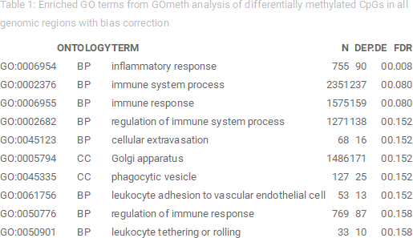

```r
knitr::include_graphics("/Users/15713/Documents/Project/Table_1_GO_default_bias_correction.png")
```

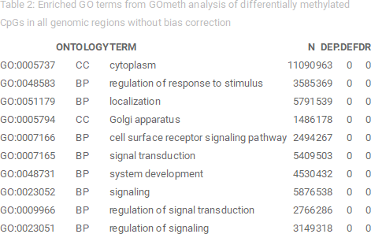

```r
knitr::include_graphics("/Users/15713/Documents/Project/Table_2_GO_default_without_bias_correction.png")
```

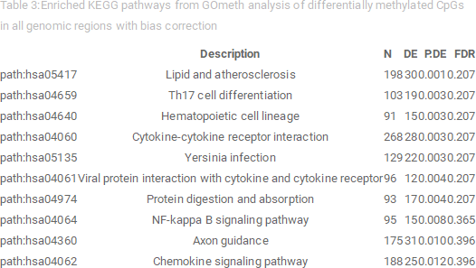

```r
knitr::include_graphics("/Users/15713/Documents/Project/Table_3_KEGG_default_with_bias_correction.png")
```

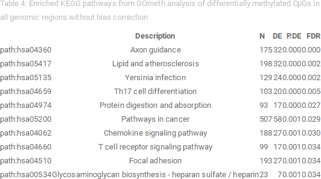

```r
knitr::include_graphics("/Users/15713/Documents/Project/Table_4_KEGG_default_without_bias_correction.png")
```

### Promoter: TSS200, TSS1500, 1stExon

In order to study the enriched gene ontology terms associated with CpGs located in the promoter region, an enrichment analysis combined the following genomic regions: TSS200, TSS1500, and 1stExon. The overall GO categories enriched using bias correction was biological process; however, these results were not statistically significant (Table 5). The overall and specific GO categories yielded from the enrichment method without bias correction were biological processes and regulation of immune system processes, respectively (Table 6).

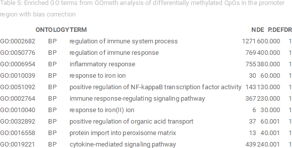

```r
knitr::include_graphics("/Users/15713/Documents/Project/Table_5_GO_promoter_with_bias_correction.png")
```

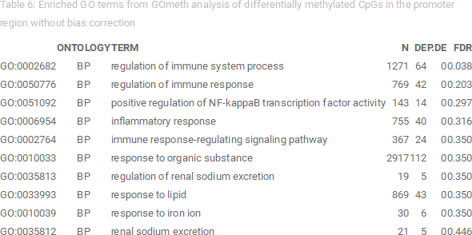

```r
knitr::include_graphics("/Users/15713/Documents/Project/Table_6_GO_promoter_without_bias_correction.png")
```

The enriched KEGG pathways for CpGs in the promoter region were similar with and without bias correction. The statistically significant enriched KEGG pathway is the Th17 cell differentiation pathway with the FDR value of 0.042(Table 8).

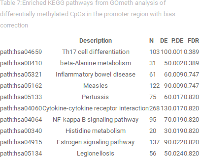

```r
knitr::include_graphics("/Users/15713/Documents/Project/Table_7_KEGG_promoter_with_bias_correction.png")
```

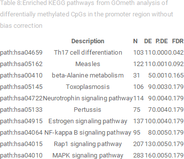

```r
knitr::include_graphics("/Users/15713/Documents/Project/Table_8_KEGG_promoter_without_bias_correction.png")
```

### Body

The significant GO category from the enrichment test of the CpGs in the body genomic region was molecular function (Table 9 and 10). When accounting for bias correction the major GO terms were GTPase regular activity, nucleoside-triphosphatase regular activity and GTPase activator activity (Table 9).

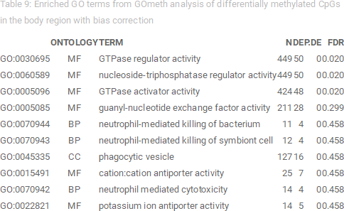

```r
knitr::include_graphics("/Users/15713/Documents/Project/Table_9_GO_body_with_bias_correction.png")
```

[figure not shown]

```r
knitr::include_graphics("/Users/15713/Documents/Project/Table_10_GO_body_without_bias_correction.png")
```

### 5’ UTR Region Enrichment Results

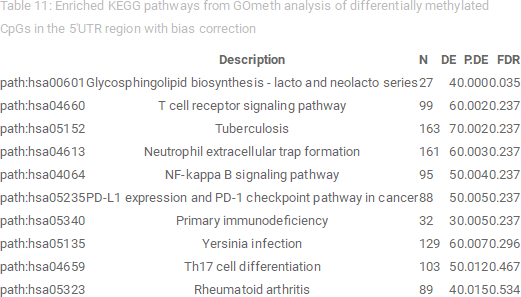

```r
knitr::include_graphics("/Users/15713/Documents/Project/Table_11_KEGG_5_with_bias_correction.png")
```

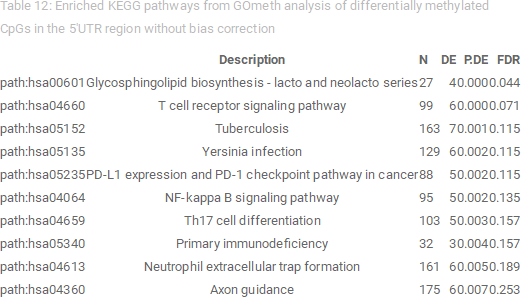

```r
knitr::include_graphics("/Users/15713/Documents/Project/Table_12_KEGG_5_without_bias_correction.png")
```

No statistically significant gene ontology or KEGG pathway results yielded from the enrichment tests that analyzed CpGs in the TSS200 and 3’UTR genomic regions. Refer to supplemental tables 9 - 12 for TSS200 results and supplemental tables 13 - 16 for 3’ UTR results.

# Discussion

### Comparing overall GO categories

It is of importance to note that utilization of bias correction produced similar overall GO categories (BP for biological process, MF for molecular function and CC for cellular component) to enrichment methods without bias correction. The difference in results between the two methods lies in the specific GO terms and KEGG pathways. The baseline study reported gene ontology terms that belonged to the biological processes and cellular competent categories.

### Strengths and Limitations of the Study

The strengths of this study are that the data supports the previous findings indicated in the York et. al. study, which highlights that in addition to the clusterProfiler package, the missMethyl package is an effective method that can perform enrichment analysis with and without bias correction for overall and specific genomic regions. Given that the missMethyl package allowed passing specific genomic regions as parameters, the results showed what component could be driving the enrichment. Overall, the current study, which accounted for the multi-probe bias correction, provided consistent results with the clusterProfiler package that did not use bias correction methods. Although there were no major differences in enriched GO terms and KEGG pathways between the current and PREG studies, it is important to note that fetal umbilical cord data was used. There may be differences in results utilizing bias correction with different data sets. Another point to take into consideration is that GO terms and KEGG pathways are limited and do not provide the whole picture of biological relevance of the enriched CpGs.

### Future prospects

This research can serve as a baseline for future studies that want to compare the differences in enriched gene ontology terms and KEGG pathways utilizing enrichment methods with and without bias correction. Researchers could expand on the findings of this study to explore other measures besides DNA methylation to understand the effects of early gestation age.

### Additional Links

Supplemental Tables: https://osf.io/5j89d/?view_only=7fcf8a761e47479ba1da715a162dae35 Full R Script: https://mfr.osf.io/render?url=https://osf.io/brfqs/?direct%26mode=render%26action=download%26mode=render

### References

Dong, D., Tian, Y., Zheng, S. C., & Teschendorff, A. E. (2019). ebGSEA: An Improved Gene Set Enrichment Analysis method for Epigenome-Wide-Association Studies, Bioinformatics, 35(18), 3514–3516. https://doi.org/10.1093/bioinformatics/btz073

Maksimovic, J., Oshlack, A. & Phipson, B. (2021). Gene Set Enrichment Analysis for Genome-wide DNA Methylation Data. Genome Biology, 22, 173. doi:10.1186/s13059-021-02388-x

Ren, X., Kuan, P. F. (2022, May 1). methylGSA: Gene Set Analysis for DNA Methylation Datasets. METHYLGSA: Gene set analysis for DNA methylation datasets. Retrieved May 11, 2022, from https://bioconductor.org/packages/devel/bioc/vignettes/methylGSA/inst/doc/methylGSA-vignette.html

York, T.P., Latendresse, S. J., Jackson-Cook, C., Lapato, D.M., Moyer, S., Wolen, A. R., Roberson-Nay, R., Do, E. K., Murphy, S.K., Hoyo, C. , Fuemmeler, B.F. & Strauss, J.F. (2020). Replicated Umbilical Cord Blood DNA Methylation Loci Associated with Gestational Age at Birth, Epigenetics, 15(11), 1243-1258. doi: 10.1080/15592294.2020.1767277

Zhang, T., de Waard, A. A., Wuhrer, M., Spaapen, R. M. (1, January 1). The role of glycosphingolipids in immune cell functions. Frontiers. Retrieved May 11, 2022, from https://www.frontiersin.org/articles/10.3389/fimmu.2019.00090/full